# The Variation in College Baseball Statistics (Batting)

Sanjay Pothula

August 23, 2019

When looking at individual college baseball data for a season, one needs to be extremely careful. During this past season, the highest amount of Plate Appearances for a single player in the SEC, Big Ten, Big 12, ACC, or PAC-12 was 346. For the MLB, a single season worth of plate appearances ~500 is typically not enough to make certain conclusions about a player unless you’re Mike Trout.

For most college baseball players, there is significant variation in their rate statistics like strikeout rate, walk rate, and etc. This is a big reason why college baseball models tend to be pretty bad because they’re typically based on the mean values. This doesn’t mean that these models are useless, but need to be viewed as distributions in order to see the uncertainty of these predictions in small samples.

The big mistake that I have made and see many people make are viewing these statistics as definitive. For example, if a player with 250 PA has a higher strikeout rate than the league average. The league average strikeout rate is normalized because it is operating under a very large sample of plate appearances. However, an individual player’s strikeout rate will have a ton of variation because of the small sample of plate appearances. Because of the different distributions between player and league statistics, it is typically hard to make this conclusion definitive based on seasonal statistics. This is why modeling the rate statistics at the per-pitch level will likely help a ton with driving down this variation because pitches normalize significantly faster than plate appearances based on sample size. As I will stress a lot, normalization helps us make better predictions!

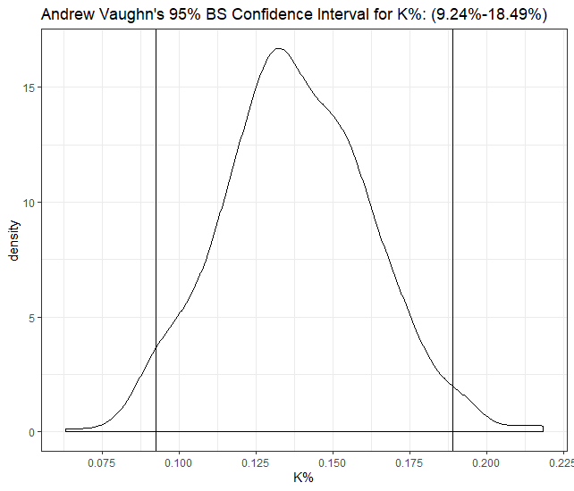

Below is a table with the 95% confidence intervals for individual player statistics with at least 50 PA in the SEC, Big Ten, Big 12, ACC, and PAC-12

|  | Name | School | Conf | Class | Pos | PA | L95% K% | U95% K% | L95% BB% | U95% BB% | L95% wOBA | U95% wOBA | L95% wRAA | U95% wRAA |
| --- | --- | --- | --- | --- | --- | --- | --- | --- | --- | --- | --- | --- | --- | --- |
| 1 | Rutschman, Adley | Oregon St. | Pac-12 | Jr | C | 266 | 10.15 | 19.17 | 23.31 | 34.21 | 0.392 | 0.533 | 23.57 | 61.11 |
| 2 | Bishop, Hunter | Arizona St. | Pac-12 | Jr | OF | 280 | 16.79 | 27.14 | 12.86 | 22.86 | 0.352 | 0.515 | 13.53 | 59.2 |
| 3 | Jung, Josh | Texas Tech | Big 12 | Jr | INF | 295 | 10.51 | 18.64 | 13.22 | 22.37 | 0.34 | 0.476 | 11.83 | 52.15 |
| 4 | Vaughn, Andrew | California | Pac-12 | Jr | INF | 238 | 9.24 | 18.49 | 17.23 | 28.57 | 0.353 | 0.518 | 11.62 | 51.07 |
| 5 | Torkelson, Spencer | Arizona St. | Pac-12 | So | INF | 289 | 11.76 | 19.38 | 10.38 | 18.34 | 0.341 | 0.47 | 10.64 | 48.18 |
| 6 | Martin, Austin | Vanderbilt | SEC | So | UT | 323 | 6.5 | 14.55 | 8.67 | 16.41 | 0.332 | 0.461 | 9.68 | 51.08 |
| 7 | Canzone, Dominic | Ohio St. | Big Ten | Jr | OF | 306 | 7.84 | 15.36 | 8.5 | 17.32 | 0.309 | 0.44 | 9.47 | 49.64 |
| 8 | Bleday, JJ | Vanderbilt | SEC | Jr | OF | 346 | 13.01 | 20.81 | 13.87 | 21.39 | 0.33 | 0.464 | 9.42 | 55.81 |
| 9 | Cannon, Cameron | Arizona | Pac-12 | Jr | INF | 276 | 6.52 | 14.86 | 8.7 | 16.67 | 0.334 | 0.472 | 8.21 | 46.52 |
| 10 | Sabato, Aaron | North Carolina | ACC | Fr | 1B | 278 | 15.11 | 25.54 | 10.07 | 18.71 | 0.335 | 0.485 | 7.99 | 49.72 |

[output cut: 731 more lines]